# Chapter 1: Exploratory Data Analysis

## Introduction

John Tukey is often regarded as one of the founding drivers for modern data science, incorporating statistical inference along with basic summary statistics to visualize and understand data.

```r
# Load libraries
suppressPackageStartupMessages(library(tidyverse))
library(curl)
library(ggtext)
library(scales)
library(patchwork)
library(kableExtra)
library(matrixStats)
library(ggrepel)
library(corrplot)
library(RColorBrewer)

# Set ggplot2 theme
my_theme <- theme(
  panel.grid = element_blank(),
  panel.background = element_rect(fill = "white", color = "black"),

  # Set axis and title themes
  plot.title = element_markdown(),
  plot.subtitle = element_markdown()
)
```

## Elements of Structured Data

The two main types of structured data (i.e., data in a table similar to an Excel spreadsheet or something similar) are numeric and categorical:

- Numeric:
  - Continuous: any real number (e.g., velocity, flow rates)
  - Discrete: counts (e.g., number of children per household)
- Categorical: fixed set of values (e.g., car models, species of fish)
  - Binary: true/false, 0/1, yes/no values
  - Ordinal: fixed set of values with specified order to denote rating (e.g., 1-5)

## Estimates of Location

The mean describes the average value, taken by summing all of the values and dividing by the total number of records (i.e., total number of observations).

```r
# Take the mean
mean(random_data)
```

```
[1] 9.940272
```

If some cases, the mean may not be an appropriate summary statistic for the dataset. For example, the presence of outliers could skew the mean and lead to eroneous conclusions. In these cases, it may be appropriate to use the trimmed mean, which is calculated by dropping a fixed set of of sorted values from each end of the distribution. The weighted mean is another variation that may be used in situations where data from some features are more important than others, due to intrinsic variability in some features, or due to sampling design that wasn’t representative of the entire population.

We can calculate the trimmed mean using the `mean()` function and declaring the `trim` argument to remove a fraction of observations from each end of the distribution before the mean is calculated.

```r
mean(random_data, trim = 0.5)
```

```
[1] 9.904327
```

We can calculate the weighted mean using the `weighted.mean()` function, which takes two arguments: `x` to define the object containing the values whose weighted mean we want to calculate; and `w`, to define an object of the same length of `x` giving the weights of each element of `x`. In the example below, we’ll use data from Siegel 1994 (also available in the help documentation) to calculate the weighted GPA, which is the GPA that considers the grade the student received in a course as well as the difficulty of the course.

```r
# GPA from Siegel 1994- example from the help documentation
wt <- c(5, 5, 4, 1)/15
x <- c(3.7, 3.3, 3.5, 2.8)

# Calculate the weighted mean pf GPA for each quarter, weighted by the course load
weighted.mean(x, wt)
```

```
[1] 3.453333
```

## Median and Robust Estimates

The median is less sensitive to the data, meaning that it is robust to outliers present in a dataset. In cases with an odd number of records, the median is the middle number; in cases with an even number of records, the median is the average between the two middle numbers that divide the data into lower and upper halves.

## Anomaly Detection

Although sometimes, outliers (extreme data points far from the mean) are mistakes made from data entry, there would be something interesting going on to warrant further investigation. In general, though, either the median or trimmed mean are used, trimming 10% of the lowest and highest values from the sorted distribution before calculating the mean, in the latter case.

## Example: Location Estimates of Population and Murder Rates

In this example, we’ll explore the murder rates across the country in the `states.csv` file.

```r
# Load states file and explore the data
states <- read_csv("./data/state.csv")

# Look at the states with the highest murder rates
states %>%
  arrange(desc(Murder.Rate)) %>%
  kable(format = "html",
        format.args = list(big.mark = ",")) %>%
  scroll_box(height = "500px",
             width = "800px") %>%
  kable_material(full_width = TRUE, "striped")

# Scale states data
states_scaled <- states %>%
  mutate(Population = Population / 1e6)
```

[output not shown]

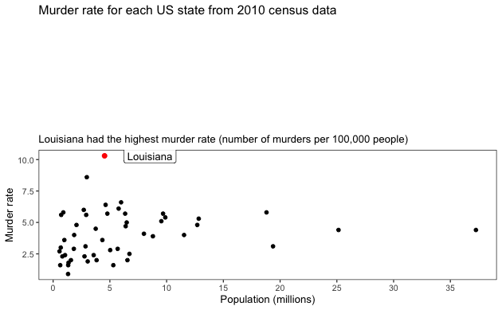

We can compute various summary statistics on this dataset to get an overview of murder rates across the United States.

| Population Size Mean | Population Size Mean (trimmed) | Population Size Median |
| --- | --- | --- |
| 6,162,876 | 4,783,697 | 4,436,370 |

We can also calculate the weighted mean and median, which will take into account the population size for each state. The key takeaway here is that both estimates are relatively similar.

| Weighted statistics Mean | Weighted statistics Median |
| --- | --- |
| 4.445834 | 4.4 |

## Estimates of Variability

Variability describes the spread of data and distinguishing it from real variability. There are a few terms to review, including deviations (differences between the observed and estimated values, like the mean, for example), variance (sum of squared deviations from the mean, divided by the sample size minus one), and the standard deviation (the square root of the variance). There are many other metrics used to describe variability, which will be demonstrated using examples below.

One metric to describe variability is the mean absolute deviation, or the average of the absolute differences between the observed and estimated values. More commonly used metrics are the variance (average of the squared deviations) and the standard deviation. The latter metric is preferred over the variance because it is in the same scale as the original data.

| mean | variance | std_dev |
| --- | --- | --- |
| 4.066 | 3.670045 | 1.915736 |

Often, the variance and standard deviation formulas use `n-1` in their denominators to generate unbiased estimates. When using just `n`, the sample estimates of the variance and standard deviations will be biased and underestimate the true population parameters, because of the constraint that the standard deviation requires calculating the sample mean.

Variance and standard deviation are both sensitive to outliers, but another metric, the median absolute deviation from the median (MAD), is not (similar to the median).

## Estimates Based on Percentiles

The percentile is the value at which a given percentage of the data are a particular value, or less. For example, if we took a sequence of numbers from 1 to 1,000 and piped them into the `quantile()` function, we’d see that the 25th percentile is 250.75. In other words, 25% of the values from 1 to 1,000 are 250.75 or less. The `IQR()` function will yield the interquartile range, or the essentially where the middle 50% of the data lie.

Below, we’ll explore the `states` dataset using the estimates of variability.

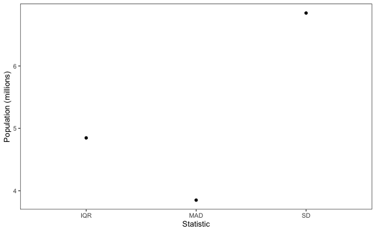

From this plot, it’s obvious that the standard deviation (SD) is about 1.7 times greater than the MAD, because it is sensitive to outliers.

## Exploring the Data Distribution

There are several additional approaches to visualizing distributions, including histograms and density plots. These two visualizations are similar, except the histograms are based on binning observations into discrete bins, while the latter involves kernel density estimation (KDE) to approximate the probability distribution. KDE is a non-parametric approach to approximating the probability distribution because sometimes data don’t conform to the standard probability distributions (e.g., if data are bimodal, or multimodal). In parametric approaches, we can describe the probability distribution using parameters. For example, if data are normally distributed, we describe the probability distribution using two parameters: the mean and standard deviation.

To describe the middle 50% of the data for various fields, or the range between the 25th and 75th percentile, we can use a boxplot. The data points outside of 1.5 times the IQR are defined as outliers (also shown). Note in the boxplots, the function call should be `ggplot(aes("", Population))`, or else there will be erroneous data on the x-axis.

[figure not shown]

## Statistical Moments

There are four moments of a distribution:

1. Location (referring to mean, median, mode)
2. Variability (e.g., standard deviation, variance, MAD)
3. Skewness (are data skewed to large or small values)
4. Kurtosis (describes the tendency for data to have extreme values)

## Exploring Binary and Categorical Data

In the next section, we’ll explore categorical data using the `dfw_airline.csv` dataset, which contains data on the number of delayed flights per year from Dallas/Fort Worth airport due to various reasons: carrier issues, air traffic control problems, weather, security, or issues with inbound flights.

| Carrier | ATC | Weather | Security | Inbound |
| --- | --- | --- | --- | --- |
| 64263.16 | 84856.5 | 11235.42 | 343.15 | 118427.8 |

These data can also be represented using a bar plot.

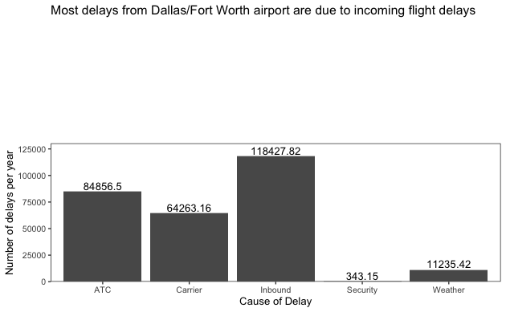

## Correlation

The correlation describes the relationship between two variables on a continuous -1 to 1 scale. It is calculated by taking the deviations from the mean for one variable, multiplied by the deviations from the mean for the second variable, and then dividing by the product of the standard deviations. In this section, we’ll explore the `sp500_px.csv` dataset, which contains 5,647 records of telecommunication stocks from 517 different companies over time. To create the plot in the textbook, we’ll also import the `sp500_sym.csv` dataset, which contains data on the company symbols and sectors. We’ll join both of these together, then filter the final dataset to only include those records for major exchange-tranded funds (ETFs) between July 2012 through June 2015.

| Date | symbol | daily_returns | sector | sector_label | sub_sector |
| --- | --- | --- | --- | --- | --- |
| 2012-07-02 | XLI | -0.376098334 | etf | EFTs | industrials |
| 2012-07-02 | QQQ | 0.096313202 | etf | EFTs | broad |
| 2012-07-02 | SPY | 0.028222544 | etf | EFTs | broad |
| 2012-07-02 | DIA | -0.242796416 | etf | EFTs | broad |
| 2012-07-02 | GLD | 0.419998000 | etf | EFTs | broad |
| 2012-07-02 | VXX | -10.400000183 | etf | EFTs | broad |
| 2012-07-02 | USO | 0.000000000 | etf | EFTs | broad |
| 2012-07-02 | IWM | 0.534640942 | etf | EFTs | broad |
| 2012-07-02 | XLE | 0.028186139 | etf | EFTs | energy |
| 2012-07-02 | XLY | 0.095758594 | etf | EFTs | consumer_discretionary |

[output cut: 990 more lines]

Now, we’ll calculate the correlation of daily returns between all companies by pivoting the data frame back to wide format. [This](https://cran.r-project.org/web/packages/corrplot/vignettes/corrplot-intro.html) site provides a thorough introduction to the various options to customize correlation plots.

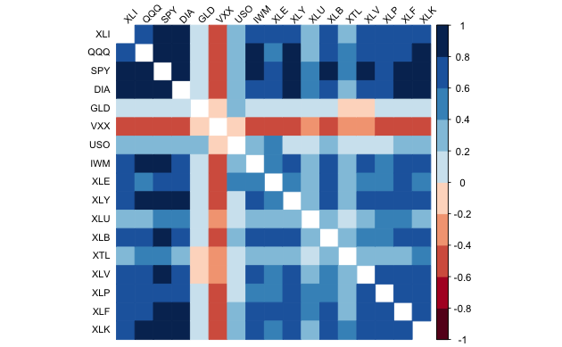

From this correlation plot, we can see that there are some ETFs that are strongly positively correlated (correlation coefficients near 1), while others are not correlated (correlation coefficients near 0), or are negatively correlated (correlation coefficients between -0.4 and -0.5). Some of the ETFs that have strong positive correlations are the S&P 500 (SPY), Invesco (QQQ), Indus (XLI), and the Dow Jones Industrial Average (DIA), among others. Let’s see what types of companies those are, and if that gives us an indication as to why they may have such strong positive correlations.

| sector | sector_label | sub_sector | symbol |
| --- | --- | --- | --- |
| etf | EFTs | industrials | XLI |
| etf | EFTs | broad | QQQ |
| etf | EFTs | broad | SPY |
| etf | EFTs | broad | DIA |

These are all rather broad ETFs. There are many other stocks that have negative correlations, including iPath Series B (VXX) and the same ETFs mentioned above.

| sector | sector_label | sub_sector | symbol |
| --- | --- | --- | --- |
| etf | EFTs | broad | VXX |

Interestingly, this is also an ETF under the broad subsector category, but the textbook describes that this particular ETF tends to track market volatility and may be negatively correlate with other ETFs.

## Scatterplot

In addition to using correlation plots, scatterplots can be used to understand the relationship between two variables. For example, we can create a scatterplot to visualize the correlation between daily returns from Verizon (VZ) and AT&T (T) from the telecommunications datasets.

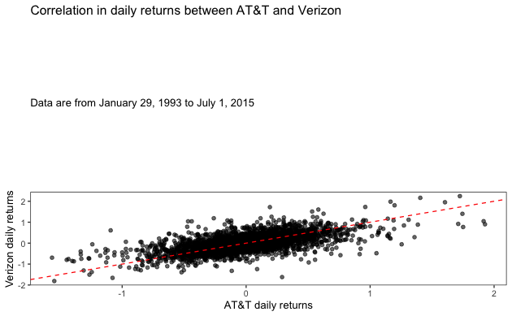

From this plot, we can see that on most dates, the returns are near zero, but when they do fluctuate, they tend to fluctuate together (i.e., when Verizon returns increase, so do AT&T).

## Hexagonal Binning and Contours

In this section, we’ll use the `kc_tax.csv` dataset, which contains tax-assessed vales for residential properties in King County, WA (population estimate of 2,252,782 in 2019), which includes cities like Seattle and Kent. We’ll filter the dataset to include homes with tax-assessed value less than $750,000 and living space between 100 and 3,500 square feet.

```r
# Import data
kc_tax <- read_csv("./data/kc_tax.csv")
```

Now, we’ll bin records into hexagonal bins to explore the relationship between tax-assessed value and square feet.

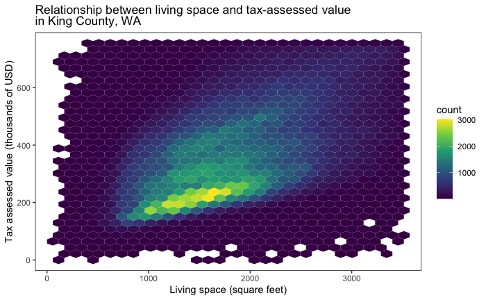

There is a distinctive band where many of the records are binned, which generally indicates that homes with more square feet tend to increase in tax-assessed value. However, we can also see that there are at least two distinct bands with fewer records above that main band, indicating there are homes with the same square footage with higher tax-assessed value. It seems plausible that the homes with the highest tax-assessed value could be in areas like Seattle or suburbs directly outside of the city. We can explore the relationship between these variables using a contour plot as well.

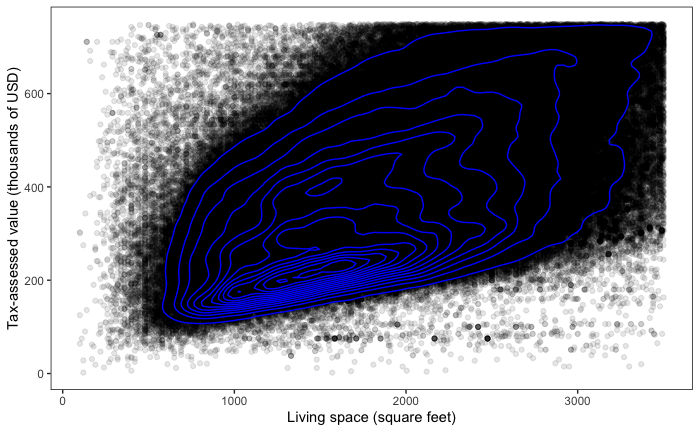

Contour plots show the same general relationship as hexagonal binning plots, but use contour lines to represent the density of records. The closer the contour lines are together, the higher the density of records. Using this approach, we can see the same general density of records in the main band, and several others above as well.

## Contingency tables for two categorical variables

This section focuses on displaying counts of categorical data using the `loan_data.csv` dataset. This is the larger dataset from the textbook that contains information on status of each loan, the loan amount, term, annual income of the borrower, whether or not the borrower is a renter or a homeowner, the purpose of the loan (e.g., debt consolidation, small business, major purchase, etc), and other data.

| row_number | status | loan_amnt | term | annual_inc | dti | payment_inc_ratio | revol_bal | revol_util | purpose | home_ownership | delinq_2yrs_zero | pub_rec_zero | open_acc | grade | outcome | emp_length | purpose_ | home_ | emp_len_ | borrower_score |
| --- | --- | --- | --- | --- | --- | --- | --- | --- | --- | --- | --- | --- | --- | --- | --- | --- | --- | --- | --- | --- |
| 1 | Charged Off | 2500 | 60 months | 30000 | 1.00 | 2.39320 | 1687 | 9.4 | car | RENT | 1 | 1 | 3 | 4.8 | default | 1 | major_purchase | RENT | > 1 Year | 0.65 |
| 2 | Charged Off | 5600 | 60 months | 40000 | 5.55 | 4.57170 | 5210 | 32.6 | small_business | OWN | 1 | 1 | 11 | 1.4 | default | 5 | small_business | OWN | > 1 Year | 0.80 |
| 3 | Charged Off | 5375 | 60 months | 15000 | 18.08 | 9.71600 | 9279 | 36.5 | other | RENT | 1 | 1 | 2 | 6.0 | default | 1 | other | RENT | > 1 Year | 0.60 |
| 4 | Charged Off | 9000 | 36 months | 30000 | 10.08 | 12.21520 | 10452 | 91.7 | debt_consolidation | RENT | 1 | 1 | 4 | 4.2 | default | 1 | debt_consolidation | RENT | > 1 Year | 0.50 |
| 5 | Charged Off | 10000 | 36 months | 100000 | 7.06 | 3.90888 | 11997 | 55.5 | other | RENT | 1 | 1 | 14 | 5.4 | default | 4 | other | RENT | > 1 Year | 0.55 |
| 6 | Charged Off | 21000 | 36 months | 105000 | 13.22 | 8.01977 | 32135 | 90.3 | debt_consolidation | RENT | 1 | 1 | 7 | 5.8 | default | 11 | debt_consolidation | RENT | > 1 Year | 0.40 |

```r
# Create a contingency table for the categorical data
loan_data %>%
  group_by(status, term) %>%
  summarise(n = n()) %>%
  pivot_wider(names_from = "status",
              values_from = "n") %>%
  group_by(term, `Charged Off`, Default, `Fully Paid`) %>%
  mutate(Total = `Charged Off` + Default + `Fully Paid`) %>%
  kbl(format.args = list(big.mark = ","), caption = "Table of charged off, default, and fully paid loans by term") %>%
  kable_styling(full_width = FALSE,
                "striped") %>%
  kable_classic_2()
```

Table of charged off, default, and fully paid loans by term

| term | Charged Off | Default | Fully Paid | Total |
| --- | --- | --- | --- | --- |
| 36 months | 15,156 | 145 | 18,764 | 34,065 |
| 60 months | 7,294 | 76 | 3,907 | 11,277 |

## Categorical and numeric data

We can visualize differences between counts across categorical variables using `airline_stats.csv`, which contains data on the daily percentage of flights that were due to delays from carriers, air traffic control (ATC), or weather, by airline.

Subset of airline statistics data with delays for each category by airline

| pct_carrier_delay | pct_atc_delay | pct_weather_delay | airline |
| --- | --- | --- | --- |
| 8.153226 | 1.971774 | 0.7620968 | American |
| 5.959924 | 3.706107 | 1.5858779 | American |
| 7.157270 | 2.706231 | 2.0267062 | American |
| 12.100000 | 11.033333 | 0.0000000 | American |
| 7.333333 | 3.365591 | 1.7741935 | American |
| 6.163889 | 3.225000 | 0.9750000 | American |

We can visualize the distribution of counts for each category by airline using boxplots.

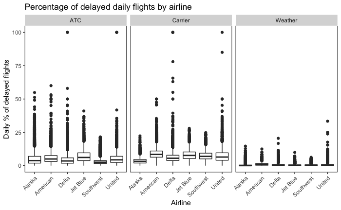

Southwest has the lowest percentage of delayed daily flights due to ATC issues, but Alaska Airlines has the lowest due to carrier issues. There are only marginal differences in the median daily percentage of delayed flights due to weather, presumably because if weather in a given location has delayed one carrier, it’s likely it will delay another carrier as well (assuming we’re not considering location-specific flight patterns for some airlines). We can also see this represented in a violin plot, which shows the density of the distribution along the y-axis as well.

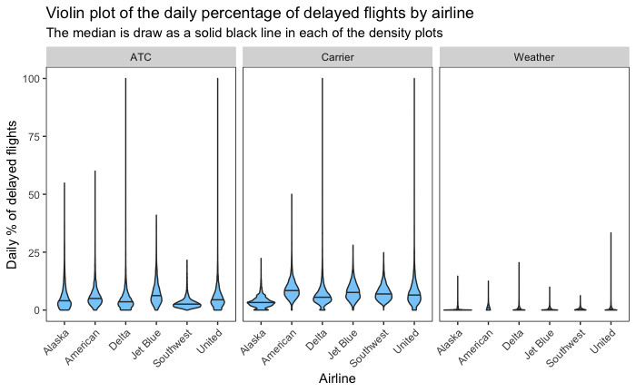

## Visualizing Multiple Variables

In this section, we’ll visualize multiple variables conditionally using `facet_wrap()`. We’ll use the `kc_tax0` data to further explore some of the differences in tax-assessed value of homes with the same square footage but in different zip codes. For example, we’ll filter only the zip codes 98105, 98108, 98126, and 98188, which correspond to the University District and Laurelhurst, South Seattle and Georgetown near the Boeing factory, West Seattle, and McMicken Heights adjacent to Seattle-Tacoma International Airport.

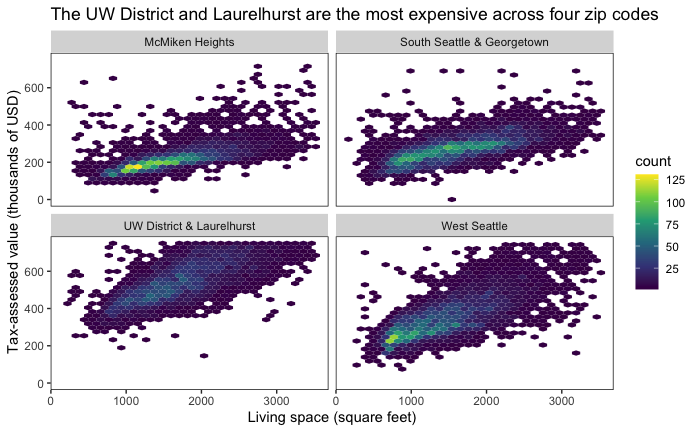

The figure above demonstrates holding all other factors constant, the tax-assessed value of a home in the UW District or Laurelhurst neighborhoods will tend to be more expensive than a home of the same square footage in another Seattle neigborhood like McMiken Heights, South Seattle and Georgetown, or West Seattle.